### In short

I am a cognitive neuroscientist based in Oslo, Norway, and works at the Center for Lifespan Changes in Brain and Cognition. I’m passionate about cognitive neuroscience, using R and teaching the world the wonders of R. Doing all I can to improve gender diversity in the R-community though [RLadies-Oslo](https://twitter.com/RLadies_Oslo).

### Education

2012 - 2016 PhD in Cognitive Neuroscience, University of Oslo  
2009 - 2011 MPhil in Cognitive Neuroscience, University of Oslo  
2005 - 2009 BA in Cognitive Psychology, University of Oslo

### Publications

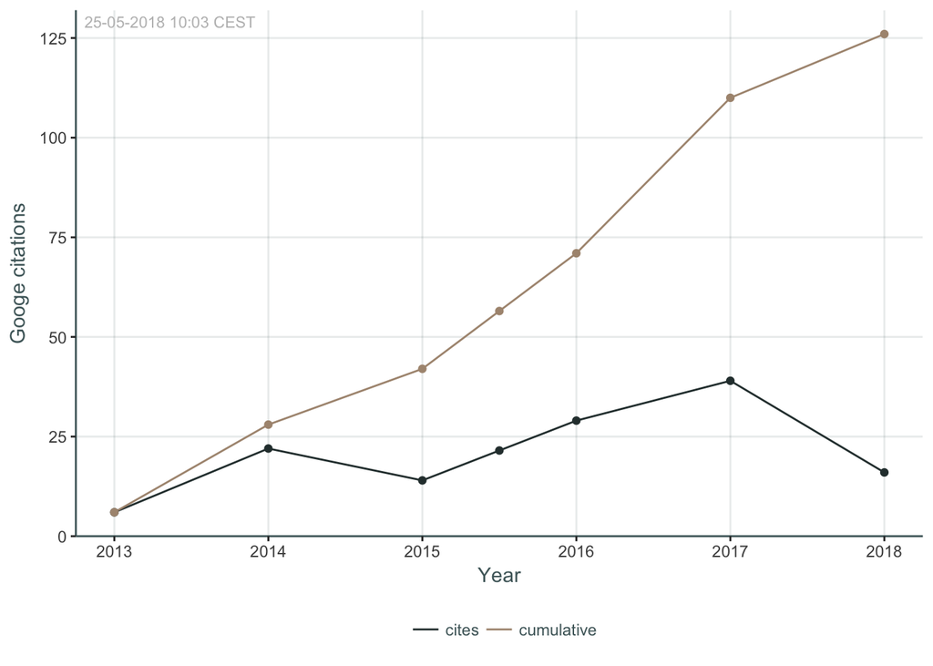

KB Walhovd, AM Fjell, R Westerhausen, L Nyberg, KP Ebmeier, … (2018) Healthy minds from 0–100 years: Optimising the use of European brain imaging cohorts (“Lifebrain”) *European Psychiatry* *47, 76-87*  
AM **Mowinckel**, D Alnæs, ML Pedersen, S Ziegler, M Fredriksen, … (2017) Increased default-mode variability is related to reduced task-performance and is evident in adults with ADHD [*NeuroImage: Clinical*](https://scholar.google.no/scholar?oi=bibs&hl=en&cluster=15217082774564824421) *16, 369-382*  
S Ziegler, ML Pedersen, AM **Mowinckel**, G Biele (2016) Modelling ADHD: a review of ADHD theories through their predictions for computational models of decision-making and reinforcement learning [*Neuroscience & Biobehavioral Reviews*](https://scholar.google.no/scholar?oi=bibs&hl=en&cluster=11108308558386894134) *71, 633-656*  
A **Mowinckel** (2016) Chronic fatigue syndrome and experience with the Lightning Process *TIDSSKRIFT FOR DEN NORSKE LAEGEFORENING* *136 (7), 588-588*  
AM **Mowinckel**, ML Pedersen, E Eilertsen, G Biele (2015) A meta-analysis of decision-making and attention in adults with ADHD [*Journal of Attention Disorders*](https://scholar.google.no/scholar?oi=bibs&hl=en&cluster=9967029451223534628) *19 (5), 355-367*  
AM **Mowinckel**, T Espeseth, LT Westlye (2012) Network-specific effects of age and in-scanner subject motion: a resting-state fMRI study of 238 healthy adults [*Neuroimage*](https://scholar.google.no/scholar?oi=bibs&hl=en&cluster=13651232777638540310) *63 (3), 1364-1373*